# Manipulation of Data

Mahbubul Majumder, PhD  
Sep 18, 2014

### What is data manipulation?

- Is it data doctoring?
- Why do we need this?
  - sorting, rearranging
  - merging and grouping
  - creating new variables
  - change the variable types
  - aggregating
- How can we do this effectively?
  - grammar of data manipulation

### Changing variable types

```r
m <- c("5","7","9","4","8")
mf <- factor(m)
mf
```

```
[1] 5 7 9 4 8
Levels: 4 5 7 8 9
```

```r
as.numeric(mf)
```

```
[1] 2 3 5 1 4
```

```r
as.numeric(m)
```

```
[1] 5 7 9 4 8
```

```r
as.numeric(as.character(mf))
```

```
[1] 5 7 9 4 8
```

- What did we learn?
  - character to factor
  - character to numeric
  - factor to character
  - factor to numeric conversion ??
- Ordered factor levels

```r
mf[1]<mf[2]
```

```
[1] NA
```

```r
vo <- factor(m, ordered=1:5)
vo
```

```
[1] 5 7 9 4 8
Levels: 4 < 5 < 7 < 8 < 9
```

### Sorting, ordering and arranging data

```r
x <- c(4,5,8,9,3)
order(x)
```

```
[1] 5 1 2 3 4
```

```r
x[order(x)]
```

```
[1] 3 4 5 8 9
```

```r
x[order(-x)]
```

```
[1] 9 8 5 4 3
```

```r
y <- c("A","F","G","E","D")
y[order(x)]
```

```
[1] "D" "A" "F" "G" "E"
```

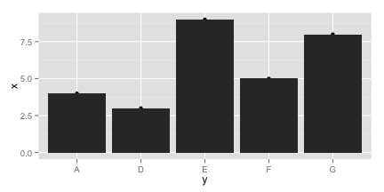

```r
qplot(y,x) + geom_bar(stat="identity")
```

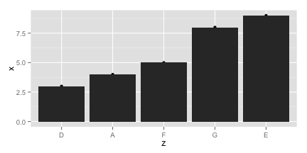

```r
z <- reorder(y,x)
qplot(z,x) + geom_bar(stat="identity")
```

### Rearranging data

```r
head(tips)
```

```
  total_bill  tip    sex smoker day   time size
1      16.99 1.01 Female     No Sun Dinner    2
2      10.34 1.66   Male     No Sun Dinner    3
3      21.01 3.50   Male     No Sun Dinner    3
4      23.68 3.31   Male     No Sun Dinner    2
5      24.59 3.61 Female     No Sun Dinner    4
6      25.29 4.71   Male     No Sun Dinner    4
```

```r
ordered_tips <- tips[order(-tips$tip),]
head(ordered_tips)
```

```
    total_bill   tip  sex smoker  day   time size
171      50.81 10.00 Male    Yes  Sat Dinner    3
213      48.33  9.00 Male     No  Sat Dinner    4
24       39.42  7.58 Male     No  Sat Dinner    4
60       48.27  6.73 Male     No  Sat Dinner    4
142      34.30  6.70 Male     No Thur  Lunch    6
184      23.17  6.50 Male    Yes  Sun Dinner    4
```

### Aggregating data

Aggregation can be done using any function

**Note:** The function may return more than one row

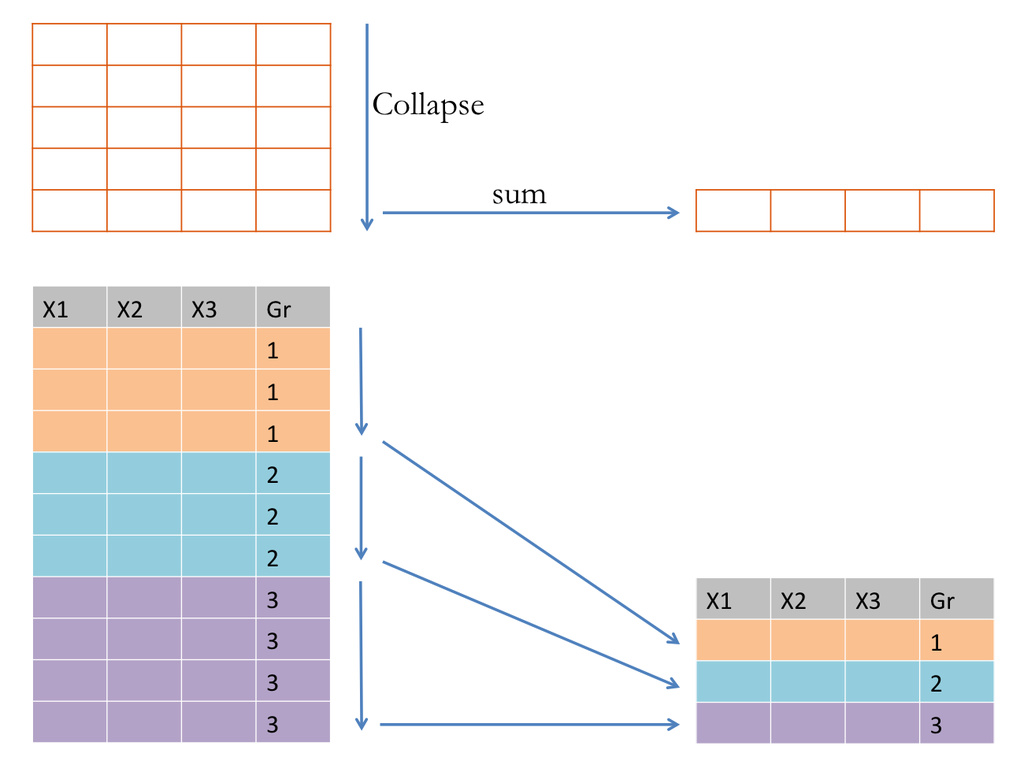

### Apply family

- `apply() tapply() sapply()`

```r
m <- matrix(1:6,ncol=3)
df <- data.frame(m)
df
```

```
  X1 X2 X3
1  1  3  5
2  2  4  6
```

```r
apply(df,2,sum)
```

```
X1 X2 X3
 3  7 11
```

```r
apply(df,1,sum)
```

```
[1]  9 12
```

```r
x <- c(3,4,6,7,8,9)
y <- c(1,1,2,2,3,3)
tapply(x,y,mean)
```

```
  1   2   3
3.5 6.5 8.5
```

```r
foo <- function(x){
  return(2^x)
  }
sapply(x,foo)
```

```
[1]   8  16  64 128 256 512
```

- `?mapply ?lapply ?vapply`
- Quiz:  
  `sapply(x,'+',1)`  
  `mapply('+',x,1)`

### Merging and augmentation of data

```r
df1
```

```
  v1 v2
1  a  5
2  a  8
3  b  3
4  c  4
5  b  5
```

```r
df2
```

```
  w1   w2
1  b john
2  c Eric
```

- Suppose we want to merge based on columns `v1` and `w1`. How can we do that?

```r
merge(df1,df2,by.x='v1',by.y='w1')
```

```
  v1 v2   w2
1  b  3 john
2  b  5 john
3  c  4 Eric
```

- Columns `v1` and `w1` should be comparable
- If columns `v1` and `w1` are texts, it is wise to change them to lower case to make sure there is no trouble in comparing.
- `? tolower()`
- `? merge()`
- Quiz: When and why we should do the following?

```r
merge(df1,df2,by.x='v1',by.y='w1',
      all.x=TRUE)
```

### Standardization of data

- We have some data that shows weights of different animals

```r
df
```

```
  mice.wt lion.wt whale.wt
1       1     301     2988
2       3     280     3036
3       1     312     3047
4       7     269     2956
5       4     308     3000
6       1     283     3021
```

- How can we compare?
- We need to change them in such a way that they become unit free
- One way to do it is to standardize  
  `(x - center)/scale`

```r
scale(df)
```

```
     mice.wt lion.wt whale.wt
[1,] -0.7634  0.5116  -0.5954
[2,]  0.0694 -0.7046   0.8335
[3,] -0.7634  1.1486   1.1610
[4,]  1.7351 -1.3416  -1.5480
[5,]  0.4858  0.9169  -0.2382
[6,] -0.7634 -0.5309   0.3870
attr(,"scaled:center")
 mice.wt  lion.wt whale.wt
   2.833  292.167 3008.000
attr(,"scaled:scale")
 mice.wt  lion.wt whale.wt
   2.401   17.268   33.592
```

- Now three columns are comparable
- Quiz:  
  Give a situation where we need to do this